# Apunte 6: Funciones No Lineales y Transformaciones Logarítmicas

Econometría para la gestión · Ingeniería Comercial

Prof. Juan Pablo Carrasco

16 de noviembre de 2026

# **Introducción**

En el análisis de decisiones gerenciales y económicas, la naturaleza de las relaciones causales rara vez responde a una simple línea recta. Si bien el modelo de regresión lineal múltiple (RLM) exige linealidad estricta en los parámetros ($\beta_k$), no impone restricción alguna sobre la forma funcional de las variables explicativas o dependientes.

En la práctica económica, los fenómenos presentan con frecuencia comportamientos de rendimientos marginales crecientes o decrecientes, tasas de crecimiento exponencial o elasticidades constantes.La incorporación de funciones no lineales, como por ejemplo, términos cuadráticos y transformaciones logarítmicas, permite modelar con precisión estos comportamientos complejos sin sacrificar la estimación por Mínimos Cuadrados Ordinarios (MCO).

El objetivo de este apunte es revisar la teoría, la interpretación analítica y la estimación empírica de los modelos cuadráticos y logarítmicos basándose en los fundamentos de Gujarati y Porter (2010) y Wooldridge (2015), utilizando bases de datos clásicas en R.

# Funciones Cuadráticas y Efectos Marginales Variables

La inclusión de un término cuadrático ($X^2$) en un modelo econométrico es una de las estrategias más utilizadas para relajar el supuesto de efectos marginales constantes. En la teoría económica, la Ley de Rendimientos Marginales Decrecientes postula que, a partir de cierto umbral, añadir unidades sucesivas de un factor productivo o de gestión genera incrementos cada vez menores en la variable de desempeño.

Consideremos un modelo de regresión no lineal en las variables pero estrictamente lineal en sus parámetros:

$$Y_i = \beta_0 + \beta_1 X_i + \beta_2
X_i^2 + u_i$$

Donde:

$\beta_0$: Representa el intercepto global del modelo.

$\beta_1$: Coeficiente asociado al efecto lineal de $X$ sobre $Y$.

$\beta_2$: Coeficiente que captura la curvatura (no linealidad).

- Si $\beta_2 < 0$, la función de regresión es estrictamente cóncava (forma de “U” invertida), lo que denota rendimientos marginales decrecientes hasta alcanzar un punto máximo.
- Si $\beta_2 > 0$, la función es estrictamente convexa (forma de “U”), lo que denota rendimientos marginales crecientes a partir de un valor mínimo.

## El Efecto Marginal y el Análisis de Derivadas Parciales

En un modelo lineal simple ($Y = \beta_0 + \beta_1 X$), el impacto de una variación en la regresora es constante e idéntico a $\beta_1$ para cualquier individuo de la muestra, independientemente de su nivel base.

En contraste, al incorporar el término cuadrático, el efecto marginal (EM) deja de ser un número fijo y se transforma en una función dependiente del nivel específico de $X$. Esto se obtiene calculando la derivada parcial (o total) de la esperanza condicional de $Y$ respecto a $X$:

$$\text{EM} = \frac{dY}{dX} = \beta_1 +
2\beta_2 X_i$$

La presencia de $X_i$ en la expresión del efecto marginal implica que el impacto de la variable explicativa varía a lo largo del dominio de la distribución:

**1** .Para valores bajos de $X$, el efecto neto está dominado por el término lineal $\beta_1$ (asumiendo $\beta_1 > 0$).

**2** .A medida que $X$ aumenta, el segundo término ($2\beta_2 X_i$) resta magnitud de forma progresiva (si $\beta_2 < 0$), reflejando el agotamiento paulatino del estímulo económico.

## Deducción Analítica del Punto de Inflexión (Vértice Óptimo)

Para la toma de decisiones estratégicas, resulta fundamental determinar el nivel crítico $X^*$ donde el rendimiento marginal del factor alcanza su punto de saturación (máximo rendimiento) o su punto de inflexión.

Matemáticamente, este punto crítico se encuentra igualando el efecto marginal a cero ($\frac{dY}{dX} = 0$), maximizando o minimizando la función cuadrática:

$$\beta_1 + 2\beta_2 X^* = 0$$

Despejando analíticamente el valor óptimo de $X^*$:

$$X^* =
-\frac{\beta_1}{2\beta_2}$$

- **Condición de Máximo** ($\beta_2 < 0$): Si el término cuadrático es negativo, la segunda derivada es $\frac{d^2Y}{dX^2} = 2\beta_2 < 0$, lo que confirma que el vértice $X^*$ corresponde a un punto de máximo rendimiento.
- **Interpretación:** Si evaluamos la experiencia laboral sobre los salarios o la productividad de una planta en función de la inversión en capital físico, el vértice $X^*$ determina exactamente el umbral crítico donde las ganancias marginales se anulan. Operar más allá de $X^*$ implica rendimientos decrecientes netos que pueden deteriorar la eficiencia organizacional.

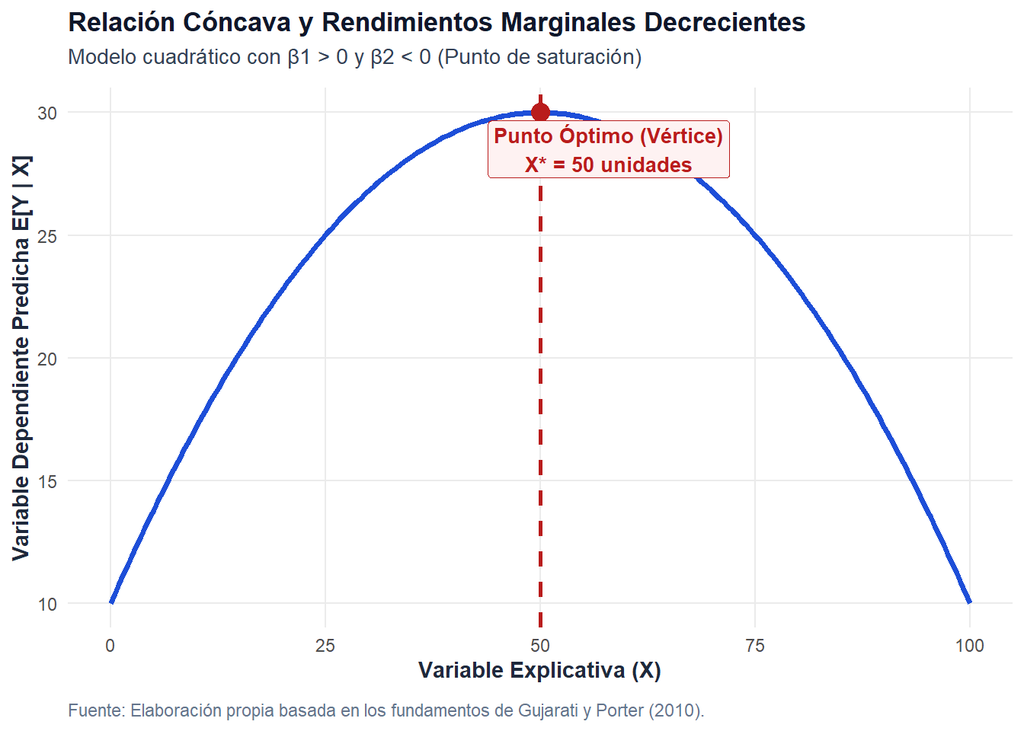

```r
library(ggplot2)

# ==============================================================================
# 1. PARÁMETROS DEL ESCENARIO CUADRÁTICO
# ==============================================================================
b0 <- 10.0
b1 <- 0.8
b2 <- -0.008

# ==============================================================================
# 2. CREACIÓN DE GRILLA Y CÁLCULO DE Y PREDICHO
# ==============================================================================
x_seq <- seq(0, 100, length.out = 200)
y_seq <- b0 + b1 * x_seq + b2 * (x_seq^2)
df_cuad <- data.frame(X = x_seq, Y = y_seq)

# Cálculo analítico del vértice
x_star <- -b1 / (2 * b2)
y_star <- b0 + b1 * x_star + b2 * (x_star^2)

# ==============================================================================
# 3. VISUALIZACIÓN GRÁFICA
# ==============================================================================
ggplot(df_cuad, aes(x = X, y = Y)) +
  geom_line(color = "#1d4ed8", linewidth = 1.3) +
  geom_vline(xintercept = x_star, linetype = "dashed", color = "#b91c1c", linewidth = 1) +
  geom_point(aes(x = x_star, y = y_star), color = "#b91c1c", size = 4) +
  annotate("label", x = x_star + 8, y = y_star - 1.5,
           label = paste0("Punto Óptimo (Vértice)\nX* = ", x_star, " unidades"),
           color = "#b91c1c", fill = "#fef2f2", fontface = "bold", size = 3.5) +
  labs(
    title = "Relación Cóncava y Rendimientos Marginales Decrecientes",
    subtitle = "Modelo cuadrático con β1 > 0 y β2 < 0 (Punto de saturación)",
    x = "Variable Explicativa (X)",
    y = "Variable Dependiente Predicha E[Y | X]",
    caption = "Fuente: Elaboración propia basada en los fundamentos de Gujarati y Porter (2010)."
  ) +
  theme_minimal(base_size = 11) +
  theme(
    plot.title = element_text(face = "bold", size = 13, color = "#0f172a"),
    plot.subtitle = element_text(size = 10.5, color = "#334155", margin = margin(b = 10)),
    plot.caption = element_text(size = 8.5, color = "#64748b", hjust = 0, margin = margin(t = 10)),
    axis.title = element_text(face = "bold", color = "#1e293b"),
    panel.grid.minor = element_blank()
  )
```

# **Modelos Logarítmicos:** Teoría y Aplicación Económica

En la modelización econométrica, el supuesto de linealidad estricta entre las variables originales suele entrar en contradicción con la naturaleza de los fenómenos socioeconómicos y empresariales. Variables clave como los *salarios*, el *PIB per cápita*, el *consumo de los hogares* o la *inversión en activos fijos* no crecen de manera aditiva constante, sino que responden a dinámicas multiplicativas, de interés compuesto o de rendimientos marginales decrecientes (Gujarati y Porter, 2010; Wooldridge, 2015).

Las **transformaciones logarítmicas** constituyen una de las herramientas analíticas más potentes de la econometría moderna. Al aplicar el operador logaritmo natural ($\ln$) a las series de datos, se logra una triple ventaja metodológica y empírica:

**1**. **Linealidad en los Parámetros**: Permiten estimar relaciones no lineales entre las variables originales mediante el método de Mínimos Cuadrados Ordinarios (MCO), preservando la linealidad esencial en los parámetros $\beta_k$ exigida por el teorema de Gauss-Markov.

**2**. **Interpretación Económica Directa (Elasticidades y Semielasticidades)**: Transforman coeficientes absolutos en tasas de variación porcentual, elasticidades constantes o tasas de crecimiento compuesto, facilitando la lectura gerencial y la formulación de políticas públicas.

**3**. **Estabilización de la Varianza y Normalidad**: Atenúan la asimetría de las distribuciones de cola larga (típicas de variables monetarias) y reducen los problemas de heterocedasticidad al comprimir la escala de los datos de alta magnitud.

## **Formas Funcionales**

### **A. Modelo Lineal-Lineal ($Y$ en niveles, $X$ en niveles)**

**Ecuación Teórica:** $Y_i = \beta_0 + \beta_1 X_i + u_i$

**Interpretación de $\beta_1$:** Un cambio absoluto de una unidad en $X$ genera un cambio absoluto de $\beta_1$ unidades en $Y$.

Ejemplo (Salarios en función de la educación en niveles):

```r
library(wooldridge)
data("wage1")

# Estimación lineal-lineal
mod_linlin <- lm(wage ~ educ, data = wage1)
summary(mod_linlin)
```

```
##
## Call:
## lm(formula = wage ~ educ, data = wage1)
##
## Residuals:
##     Min      1Q  Median      3Q     Max
## -5.3396 -2.1501 -0.9674  1.1921 16.6085
##
## Coefficients:
##             Estimate Std. Error t value Pr(>|t|)
## (Intercept) -0.90485    0.68497  -1.321    0.187
## educ         0.54136    0.05325  10.167   <2e-16 ***
## ---
## Signif. codes:  0 '***' 0.001 '**' 0.01 '*' 0.05 '.' 0.1 ' ' 1
##
## Residual standard error: 3.378 on 524 degrees of freedom
## Multiple R-squared:  0.1648, Adjusted R-squared:  0.1632
## F-statistic: 103.4 on 1 and 524 DF,  p-value: < 2.2e-16
```

> **Interpretación:** El coeficiente $\hat{\beta}_1$ de `educ` indica que por cada año adicional de educación formal, el salario por hora aumenta en 0,54 dólares por hora.

### **B. Modelo Log-Lineal / Log-Lin ($Y$ en logaritmos, $X$ en niveles)**

**Ecuación Teórica:** $\ln(Y_i) = \beta_0 + \beta_1 X_i + u_i$

**Interpretación de $\beta_1$:** Un incremento de una unidad en $X$ genera un cambio porcentual aproximado del $(100 \times \beta_1)\%$ en $Y$. Cuando el coeficiente es de mayor magnitud, el cambio porcentual exacto se calcula mediante la transformación de Halvorsen-Palmquist: $100 \times (e^{\beta_1} - 1)$.

Ejemplo (Ecuación de Mincer ampliada):

```r
# Estimación log-lin (Semilogarítmica)
mod_loglin <- lm(lwage ~ educ + exper + tenure, data = wage1)
summary(mod_loglin)
```

```
##
## Call:
## lm(formula = lwage ~ educ + exper + tenure, data = wage1)
##
## Residuals:
##      Min       1Q   Median       3Q      Max
## -2.05802 -0.29645 -0.03265  0.28788  1.42809
##
## Coefficients:
##             Estimate Std. Error t value Pr(>|t|)
## (Intercept) 0.284360   0.104190   2.729  0.00656 **
## educ        0.092029   0.007330  12.555  < 2e-16 ***
## exper       0.004121   0.001723   2.391  0.01714 *
## tenure      0.022067   0.003094   7.133 3.29e-12 ***
## ---
## Signif. codes:  0 '***' 0.001 '**' 0.01 '*' 0.05 '.' 0.1 ' ' 1
##
## Residual standard error: 0.4409 on 522 degrees of freedom
## Multiple R-squared:  0.316,  Adjusted R-squared:  0.3121
## F-statistic: 80.39 on 3 and 522 DF,  p-value: < 2.2e-16
```

> **Interpretación:** El coeficiente asociado a `educ` mide el retorno porcentual instantáneo o semielasticidad. Si $\hat{\beta}_1 = 0,092$, cada año adicional de educación incrementa el salario por hora en aproximadamente un $9,2\%$, ceteris paribus.

### **C. Lineal-Log / Lin-Log ($Y$ en niveles, $X$ en logaritmos)**

**Ecuación Teórica:** $Y_i = \beta_0 + \beta_1 \ln(X_i) + u_i$

**Interpretación de $\beta_1$:** Un incremento porcentual del $1\%$ en $X$ ($\Delta X / X = 0.01$) genera un cambio absoluto de $(\beta_1 / 100)$ unidades en $Y$.

Ejemplo (Salario absoluto en función del logaritmo de la antigüedad):

```r
wage1$ltensure <- log(wage1$tenure + 1)
mod_linlog <- lm(wage ~ ltensure, data = wage1)
summary(mod_linlog)
```

```
##
## Call:
## lm(formula = wage ~ ltensure, data = wage1)
##
## Residuals:
##     Min      1Q  Median      3Q     Max
## -7.2339 -2.0939 -0.8827  1.3385 16.4732
##
## Coefficients:
##             Estimate Std. Error t value Pr(>|t|)
## (Intercept)   4.3002     0.2297  18.719   <2e-16 ***
## ltensure      1.2911     0.1410   9.157   <2e-16 ***
## ---
## Signif. codes:  0 '***' 0.001 '**' 0.01 '*' 0.05 '.' 0.1 ' ' 1
##
## Residual standard error: 3.432 on 524 degrees of freedom
## Multiple R-squared:  0.1379, Adjusted R-squared:  0.1363
## F-statistic: 83.84 on 1 and 524 DF,  p-value: < 2.2e-16
```

> **Interpretación:** Si el coeficiente de ltensure es $\hat{\beta}_1 = 1,291$, un aumento del $1\%$ en la antigüedad del trabajador incrementa su salario absoluto en $1,291 / 100 = \$0.0129$ dólares por hora.

### **D. Modelo Log-Log o Elasticidad Constante ($Y$ en logaritmos, $X$ en logaritmos)**

**Ecuación Teórica:** $\ln(Y_i) = \beta_0 + \beta_1 \ln(X_i) + u_i$

**Interpretación de $\beta_1$:** Representa directamente la elasticidad de $Y$ con respecto a $X$. Un incremento del $1\%$ en $X$ genera un cambio porcentual exactamente igual a $\beta_1\%$ en $Y$.

Ejemplo (Log-log aplicado a variables continuas):

```r
# Modelo log-log (ejemplo teórico con wage y horas de trabajo si estuviesen disponibles, o construyendo logaritmos)
mod_loglog <- lm(log(wage) ~ log(exper + 1), data = wage1)
summary(mod_loglog)
```

```
##
## Call:
## lm(formula = log(wage) ~ log(exper + 1), data = wage1)
##
## Residuals:
##      Min       1Q   Median       3Q      Max
## -2.11000 -0.36946 -0.06413  0.33329  1.49457
##
## Coefficients:
##                Estimate Std. Error t value Pr(>|t|)
## (Intercept)     1.29666    0.06663  19.461  < 2e-16 ***
## log(exper + 1)  0.12873    0.02470   5.211  2.7e-07 ***
## ---
## Signif. codes:  0 '***' 0.001 '**' 0.01 '*' 0.05 '.' 0.1 ' ' 1
##
## Residual standard error: 0.5188 on 524 degrees of freedom
## Multiple R-squared:  0.04928,    Adjusted R-squared:  0.04746
## F-statistic: 27.16 on 1 and 524 DF,  p-value: 2.699e-07
```

> **Interpretación:** El coeficiente $\hat{\beta}_1$ es directamente una elasticidad: mide la sensibilidad porcentual de la variable dependiente ante variaciones porcentuales en la variable independiente, manteniéndose constante a lo largo de toda la función de demanda u oferta estimada. En este caso, Un incremento del 1% en X genera un cambio porcentual exactamente igual a $\beta_1\%$ en Y.

# **Resumen Analítico de Formas Funcionales**

| **Modelo** | **Ecuación de Regresión** | **Pendiente** $\left(\dfrac{dY}{dX}\right)$ | **Elasticidad** $\left(\dfrac{dY}{dX} \cdot \frac{X}{Y}\right)$ |
| --- | --- | --- | --- |
| **Lineal** | $Y = \beta_0 + \beta_1 X$ | $\beta_1$ | $\beta_1 \left(\dfrac{X}{Y}\right)$ |
| **Log-Lineal (Log-Log)** | $\ln(Y) = \beta_0 + \beta_1 \ln(X)$ | $\beta_1\left(\dfrac{Y}{X}\right)$ | $\beta_1$ |
| **Log-Lin** | $\ln(Y) = \beta_0 + \beta_1 X$ | $\beta_1 Y$ | $\beta_1 X$ |
| **Lin-Log** | $Y = \beta_0 + \beta_1 \ln(X)$ | $\beta_1 \left(\dfrac{1}{X}\right)$ | $\beta_1 \left(\dfrac{1}{Y}\right)$ |

# Referencias Bibliográficas

- Gujarati, D. N., y Porter, D. C. (2010). Econometría (5.ª ed.). McGraw-Hill.
- Wooldridge, J. M. (2015). Introducción a la econometría: Un enfoque moderno (5.ª ed.). Cengage Learning.